# 2022 ATBC Honorary Fellows - Bruna - 2022 - Biotropica - Wiley Online Library

[Biotropica](https://onlinelibrary.wiley.com/journal/17447429)

[Volume 54, Issue 6](https://onlinelibrary.wiley.com/toc/17447429/2022/54/6) p. 1521-1522

[figure not shown]

ANNOUNCEMENT

Free Access

# 2022 ATBC Honorary Fellows

[Emilio Bruna](https://onlinelibrary.wiley.com/authored-by/Bruna/Emilio),

[Jennifer S. Powers](https://onlinelibrary.wiley.com/authored-by/Powers/Jennifer+S.),

[Lúcia G. Lohmann](https://onlinelibrary.wiley.com/authored-by/Lohmann/L%C3%BAcia+G.),

First published: 02 November 2022

https://doi.org/10.1111/btp.13170

In 1963, the Council of the Association for Tropical Biology and Conservation established the election of Honorary Fellows as “persons of long distinguished service to tropical biology.” This is the highest award given by the Association. To date, we have selected more than 100 Honorary Fellows from over 20 countries. This year, we celebrate two more outstanding Honorary Fellows who are both widely recognized for their scholarship and mentorship. On behalf of The Honorary Fellow Nomination Committee, we present the 2022 Honorary Fellows, Dr. T. Mitchell Aide and Dr. Carlos Jaramillo.

## 1 Dr. T. MITCHELL (MITCH) AIDE (UNIVERSITY OF PUERTO RICO, RIO PIEDRAS)

Dr. Aide has had a long trajectory of distinguished work in tropical ecology and conservation, including a diversity of renowned academic contributions, and international distinction as an effective teacher and an academic mentor. Mitch's academic career includes all the important milestones that define the most influential leaders in our field. He has a record of >150 peer-reviewed papers in journals such as *Science*, *Nature*, *PNAS*, *Ecology*, *Ecological Applications*, *Nature Ecology & Evolution*, *Conservation Biology*, and of course *Biotropica*. While he is perhaps most widely recognized for his influential studies of how socioeconomic changes shape land-use and biodiversity, he has worked on topics from plant–animal interactions to restoration ecology. Most recently, he has pioneered interdisciplinary collaborations with computer scientists to develop machine-learning algorithms for identifying species from recordings and the acoustic monitoring of biodiversity. While these research contributions are truly commendable, a strong argument can be made that Dr. Aide's most important and lasting contributions to tropical ecology and conservation result from his efforts in teaching and mentoring: he has advised over 35 graduate students and postdoctoral scholars, including 18 MS and 11 PhD students. With his mentees hailing from Puerto Rico, Colombia, Argentina, Panama, Uruguay, Bolivia, Brazil, Haiti, Costa Rica, Mexico, and the mainland United States, Dr. Mitchell Aide has made a long-lasting contribution to our discipline and community.

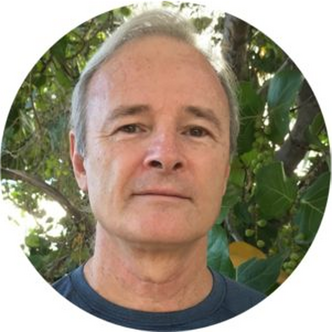

**FIGURE 1** Dr. Mitch Aide

## 2 Dr. CARLOS JARAMILLO (SMITHSONIAN TROPICAL RESEARCH INSTITUTE)

Dr. Carlos Jaramillo is a global authority on the paleo-history of Neotropical biodiversity. He and his research group have spent decades reconstructing the biological, climatological, and geological history of the Earth through a diversity of geostratigraphic techniques, including the detailed characterization of organismal communities using fossil records of pollen, dinoflagellates, and other organisms. Among his myriad contributions, he and his collaborators were able to capitalize on the Panama Canal expansion to better understand the formation of the Panama Land Bridge and the contributions of the Great American Biotic Interchange (GABI) to patterns of biodiversity in the Americas. Carlos and his collaborators also discovered and excavated the oldest tropical rainforest to date in one of the world's largest coal mines, near Cerrejón in his native Colombia. Among the discoveries made at this site was the largest terrestrial snake known to date, *Titanoboa cerrejonensis*, of which artistic renditions captivated international attention. These and other efforts resulted in 250 remarkable research publications, many written with the generation of future scientists he has mentored, including over 135 student interns, 35 thesis and dissertation students, and 34 postdoctoral scholars. Collectively, they have shown us how the tropics dramatically transitioned in 120 million years from a biome without flowering plants to an ecosystem in which they are dominant, further underscoring the magnitude of contemporary threats to their persistence.

[figure not shown]

**FIGURE 2** Dr. Carlos Jaramillo

[figure not shown]

November 2022

Pages 1521-1522